# **Object Detection Challange**

**Goal**: Build a solution for child seat localization in the passanger vehicle.

**Dataset**: The dataset used for this project is a made of synthetic data and it can be found [here](https://sviro.kl.dfki.de/).

**Problem**: Detect child seat in the passanger vehicle.

## Load libraries

```python
!pip install sahi
```

```python
# Clone the tensorflow models repository
!git clone --depth 1 https://github.com/tensorflow/models
```

```python
%%bash
sudo apt install -y protobuf-compiler
cd models/research/
protoc object_detection/protos/*.proto --python_out=.
cp object_detection/packages/tf2/setup.py .
python -m pip install .
```

```python
import tensorflow
import tensorflow_hub
import numpy
import os
import pandas


from matplotlib import pyplot
from PIL import Image

from object_detection.utils import label_map_util
from object_detection.utils import visualization_utils as viz_utils

from sahi.utils.coco import Coco, CocoCategory, CocoImage, CocoAnnotation
from sahi.utils.file import save_json

print(tensorflow.__version__)
%matplotlib inline
```

```
2.8.0
```

```python
gpus = tensorflow.config.list_physical_devices('GPU')
if gpus:
  try:
    # Currently, memory growth needs to be the same across GPUs
    for gpu in gpus:
      tensorflow.config.experimental.set_memory_growth(gpu, True)
    logical_gpus = tensorflow.config.list_logical_devices('GPU')
    print(len(gpus), "Physical GPUs,", len(logical_gpus), "Logical GPUs")
  except RuntimeError as e:
    # Memory growth must be set before GPUs have been initialized
    print(e)
```

```
1 Physical GPUs, 1 Logical GPUs
```

## Download and prepare dataset

```python
LABEL_MAP ={
    # '0':'Empty',
    '1':'Empty infant seat',
    '2':'Empty child seat',
    '3':'Person',
    '4':'Everyday object',
}
```

```python
url_bmw_i3_image = "https://sviro.kl.dfki.de/download/bmw-i3/?wpdmdl=394&refresh=624c966a289251649186410"
url_bmw_i3_annotation = "https://sviro.kl.dfki.de/download/bmw-i3-5/?wpdmdl=456&refresh=624c966b3274c1649186411"

url_tesla_model3_image = "https://sviro.kl.dfki.de/download/tesla-model-3-2/?wpdmdl=400&refresh=624dc7be5de311649264574"
url_tesla_model3_annotation = "https://sviro.kl.dfki.de/download/tesla-model-3-6/?wpdmdl=464&refresh=624dc7bf63cd11649264575"
```

```python
os.mkdir('/content/images/')
os.mkdir('/content/annotations/')
os.mkdir('/content/data/')
os.mkdir('/content/data/train')
os.mkdir('/content/data/test')
os.mkdir('/content/data/val')
```

```python
path = tensorflow.keras.utils.get_file('sviro_dataset', url_bmw_i3_image, extract=True, cache_dir='/content/images/')
path_tesla = tensorflow.keras.utils.get_file('sviro_dataset_tesla', url_tesla_model3_image, extract=True, cache_dir='/content/images/')
```

```python
path_annotation = tensorflow.keras.utils.get_file('sviro_dataset_annotation', url_bmw_i3_annotation, extract=True, cache_dir='/content/annotations/')
path_annotation_tesla = tensorflow.keras.utils.get_file('sviro_dataset_annotation_tesla', url_tesla_model3_annotation, extract=True, cache_dir='/content/annotations/')
```

```python
car_models = ['i3', 'model3']
```

```python
IMAGES_DIR = '/content/images/datasets/'
ANNOTATION_DIR = '/content/annotations/datasets/'


IMAGE_SHAPE = (896, 896)
```

```python
for dir in [IMAGES_DIR, ANNOTATION_DIR]:
  for car in car_models:
    os.rename(os.path.join(dir, car, 'test_with_labels'), os.path.join(dir, car, 'test'))
```

```python
def make_dataset(path: str, type='train', output_path='/content/data'):
  coco = Coco()

  for i in LABEL_MAP.keys():
    coco.add_category(CocoCategory(id=int(i), name=LABEL_MAP[i]))

  for car_model in car_models:
    folder_path = os.path.join(path, car_model, type, 'RGB_wholeImage')

    for file in os.listdir(folder_path)[:1000]:
      if '.png' in file:
        if '0_0_0' in file:
          continue

        filename = os.path.join(folder_path, file)
        annotation_path = filename.replace('images', 'annotations').replace('RGB_wholeImage', 'boundingBoxes_wholeImage').replace('.png', '.txt')

        # if annotation file is missing skip
        if not os.path.isfile(annotation_path):
          continue


        img = Image.open(filename)
        w, h = img.size

        # save image resized and normalized
        img = img.resize(IMAGE_SHAPE)
        # img = numpy.array(img)/255.0

        # copy image to data folder
        img.convert('RGB').save(os.path.join(output_path, type, file.replace('.png', '.jpeg')))

        w_ratio = w/img.size[0]
        h_ratio = h/img.size[1]

        coco_image = CocoImage(
            file_name=file.replace('.png', '.jpeg'),
            height=IMAGE_SHAPE[0],
            width=IMAGE_SHAPE[1]
            )

        with open(annotation_path, 'r') as f:
          bboxes = f.readlines()

          for box in bboxes:
            box = box.replace('\n', '').split(',')

            class_type, xmin, ymin, xmax, ymax = box

            xmin = int(int(xmin)/w_ratio)
            ymin = int(int(ymin)/h_ratio)
            xmax = int(int(xmax)/w_ratio)
            ymax = int(int(ymax)/h_ratio)


            width = xmax - xmin
            height = ymax - ymin

            coco_image.add_annotation(
                    CocoAnnotation(
                        bbox=[xmin, ymin, width, height],
                        category_id=int(class_type),
                        category_name=LABEL_MAP[class_type])
                    )

          coco.add_image(coco_image)

  return coco
```

```python
coco_dataset = make_dataset(IMAGES_DIR, type='train')
```

```python
save_json(coco_dataset.json, 'data/train.json')
```

```python
os.mkdir('/content/tfrecord/')
```

```python
%%bash
cd /content/models/research/object_detection/dataset_tools
python create_coco_tf_record.py --train_image_dir '/content/data/train/' --val_image_dir '/content/data/test/' --test_image_dir '/content/data/val/' --train_annotations_file '/content/data/train.json' --val_annotations_file '/content/data/test.json' --test__annotations_file '/content/data/val.json' --testdev_annotations_file '/content/data/testdev.json' --logtostderr --output_dir '/content/tfrecord'
```

```python
!rm -R /content/tfrecord/coco*
```

```python
%cd /content/
```

```
/content
```

```python
def pbtxt_from_classlist(l, pbtxt_path):

   pbtxt_text = ''
   print(l)

   for i, c in enumerate(l):
      pbtxt_text += 'item {\n    id: ' + str(i + 1) + '\n    display_name: "' + str(c) + '"\n}\n\n'

   with open(pbtxt_path, "w+") as pbtxt_file:
      pbtxt_file.write(pbtxt_text)
```

```python
pbtxt_from_classlist(LABEL_MAP.values(),'/content/data/sviro.pbtxt')
```

```
dict_values(['Empty infant seat', 'Empty child seat', 'Person', 'Everyday object'])
```

## Exploratory Data Analysis

```python
import json
```

```python
dataset_json = json.load(open('/content/data/train.json', 'r'))
```

```python
dataset_json.keys()
```

```
dict_keys(['images', 'annotations', 'categories'])
```

```python
df_annotations = pandas.DataFrame(dataset_json['annotations'])
```

```python
df_annotations['class'] = df_annotations.category_id.apply(lambda x: LABEL_MAP[str(x)])
df_annotations['class'].value_counts()/df_annotations.shape[0]
```

```
Person               0.430678
Empty child seat     0.253270
Empty infant seat    0.193341
Everyday object      0.122711
Name: class, dtype: float64
```

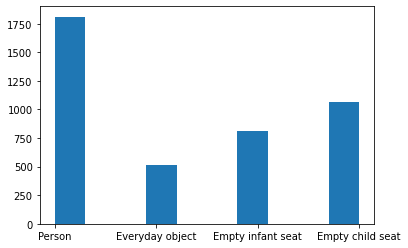

```python
df_annotations['class'].hist(grid=False)
```

```python
df_annotations.image_id.nunique()
```

```
1980
```

Trainning on 1980 images from cars BMW i3 and Tesla Model3

## Related Word

As shown in the benchmark [available here](https://sviro.kl.dfki.de/object-detection/), the team from sviro got the following results for one model of car only (BMW x5):

- mAP: 0.349
- mAP 50: 0.653
- mAP 75: 0.314

The above metrics will be the baseline for our model selection.

## Model

For this problem I chose the model Efficientdet ([arxiv](https://arxiv.org/abs/1911.09070)). This model is said to achieve state-of-the-art 55.1mAP on COCO test-dev using fewer parammeters than other SOTA algorithms. Many versions of this models is available for finetunning as it is a good model for transfer learning. The EfficientDet model uses as backbone the [EfficientNet architecture](https://ai.googleblog.com/2019/05/efficientnet-improving-accuracy-and.html) that is made to obtain better accuracy and efficiency.

For this project I will be using **EfficientDet-D3**, a 12.0M params model that achieved 47.5 mAP on COCO dataset.

### Download model

```python
!wget 'http://download.tensorflow.org/models/object_detection/tf2/20200711/efficientdet_d3_coco17_tpu-32.tar.gz'
!tar -xzvf efficientdet_d3_coco17_tpu-32.tar.gz
```

### Train model

**Data Augmentation**

Data augmentation is a very important step when training a deep neural network model as it helps the model generalize better and avoid overfitting to the data. For this project I chose only to do horizontal flipping. This function flips the image horizontaly, for example, if we have a **1_0_4** class we would get a **4_0_1** class after this process.

```python
os.mkdir('/content/training')
```

```python
%load_ext tensorboard
%tensorboard --logdir '/content/training'
```

```python
%cd /content/models/research/object_detection
!python model_main_tf2.py --pipeline_config_path=/content/data/pipeline.config --model_dir=/content/training --alsologtostderr
```

[output not shown]

[output cut: 3650 more lines]

```
 'Loss/regularization_loss': 0.043161765,
 'Loss/total_loss': 0.071562245,
 'learning_rate': 2.3460389e-06}
INFO:tensorflow:Step 30000 per-step time 0.583s
I0411 15:04:33.917802 139656348456832 model_lib_v2.py:707] Step 30000 per-step time 0.583s
INFO:tensorflow:{'Loss/classification_loss': 0.024763852,
 'Loss/localization_loss': 0.00032520705,
 'Loss/regularization_loss': 0.04316176,
 'Loss/total_loss': 0.06825082,
 'learning_rate': 0.0}
I0411 15:04:33.918104 139656348456832 model_lib_v2.py:708] {'Loss/classification_loss': 0.024763852,
 'Loss/localization_loss': 0.00032520705,
 'Loss/regularization_loss': 0.04316176,
 'Loss/total_loss': 0.06825082,
 'learning_rate': 0.0}
```

### Evaluate model

```python
%cd /content/models/research/object_detection
!python model_main_tf2.py --pipeline_config_path=/content/data/pipeline.config --model_dir=/content/training --checkpoint_dir=/content/training --alsologtostderr
```

[output not shown]

[output cut: 128 more lines]

```
I0411 15:12:11.373433 140270502217600 model_lib_v2.py:1018] 	+ DetectionBoxes_Recall/AR@100 (small): 0.000000
INFO:tensorflow:	+ DetectionBoxes_Recall/AR@100 (medium): 0.109821
I0411 15:12:11.374657 140270502217600 model_lib_v2.py:1018] 	+ DetectionBoxes_Recall/AR@100 (medium): 0.109821
INFO:tensorflow:	+ DetectionBoxes_Recall/AR@100 (large): 0.545475
I0411 15:12:11.375926 140270502217600 model_lib_v2.py:1018] 	+ DetectionBoxes_Recall/AR@100 (large): 0.545475
INFO:tensorflow:	+ Loss/localization_loss: 0.006932
I0411 15:12:11.376899 140270502217600 model_lib_v2.py:1018] 	+ Loss/localization_loss: 0.006932
INFO:tensorflow:	+ Loss/classification_loss: 0.886025
I0411 15:12:11.377894 140270502217600 model_lib_v2.py:1018] 	+ Loss/classification_loss: 0.886025
INFO:tensorflow:	+ Loss/regularization_loss: 0.043162
I0411 15:12:11.378887 140270502217600 model_lib_v2.py:1018] 	+ Loss/regularization_loss: 0.043162
INFO:tensorflow:	+ Loss/total_loss: 0.936119
I0411 15:12:11.379878 140270502217600 model_lib_v2.py:1018] 	+ Loss/total_loss: 0.936119
INFO:tensorflow:Exiting evaluation at step 30000
I0411 15:12:11.714381 140270502217600 model_lib_v2.py:1169] Exiting evaluation at step 30000
```

After trainning the model for **5000** steps we got the following metrics:

- DetectionBoxes_Precision/mAP: **0.225832**
- DetectionBoxes_Recall/AR@100: **0.408889**
- Average Precision (AP) @[ IoU=0.50:0.95 | area= all | maxDets=100 ] = 0.226
- Average Precision (AP) @[ IoU=0.50 | area= all | maxDets=100 ] = 0.604
- Average Precision (AP) @[ IoU=0.75 | area= all | maxDets=100 ] = 0.056

After trainning the model for **30000** steps we got the following metrics:

- DetectionBoxes_Precision/mAP: **0.345371**
- DetectionBoxes_Recall/AR@100: **0.537969**
- Average Precision (AP) @[ IoU=0.50:0.95 | area= all | maxDets=100 ] = 0.345
- Average Precision (AP) @[ IoU=0.50 | area= all | maxDets=100 ] = 0.646
- Average Precision (AP) @[ IoU=0.75 | area= all | maxDets=100 ] = 0.330

### Export model

```python
!python exporter_main_v2.py --trained_checkpoint_dir=/content/training --pipeline_config_path=/content/data/pipeline.config --output_directory=/content/drive/MyDrive/sviro_inference_graph
```

[output not shown]

## Visualize Results

```python
OUTPUT_IMAGE_SIZE = (12, 8)
SAVED_MODEL = '/content/drive/MyDrive/sviro_inference_graph/saved_model'
```

```python
category_index=label_map_util.create_category_index_from_labelmap("/content/data/sviro.pbtxt",use_display_name=True)
```

```python
detect_fn=tensorflow.saved_model.load(SAVED_MODEL)
```

```python
def run_detection(image_path: str):
  image_test = Image.open(image_path)
  image_test = image_test.resize(IMAGE_SHAPE)
  image_test = numpy.array(image_test)
  input_tensor = tensorflow.convert_to_tensor(image_test)
  input_tensor = input_tensor[tensorflow.newaxis, ...]

  detections = detect_fn(input_tensor)
  detections = {key:value.numpy() for key,value in detections.items()}
  image_np_with_detections = image_test.copy()
  viz_utils.visualize_boxes_and_labels_on_image_array(
      image_np_with_detections,
      detections['detection_boxes'][0],
      (detections['detection_classes'][0] + 0).astype(int),
      detections['detection_scores'][0],
      category_index,
      use_normalized_coordinates=True,
      min_score_thresh=.2,
      agnostic_mode=False,
  )
  pyplot.figure(figsize=(5,5), dpi=200)
  pyplot.axis("off")
  pyplot.imshow(image_np_with_detections)
  pyplot.show()
```

[figure not shown]

```python
run_detection('/content/data/test/i3_test_imageID_60_GT_5_0_3.jpeg')
```

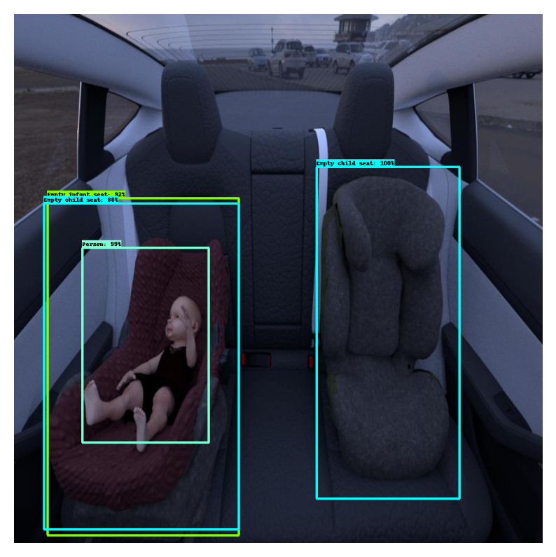

```python
run_detection('/content/data/test/tesla_test_imageID_107_GT_1_0_6.jpeg')
```

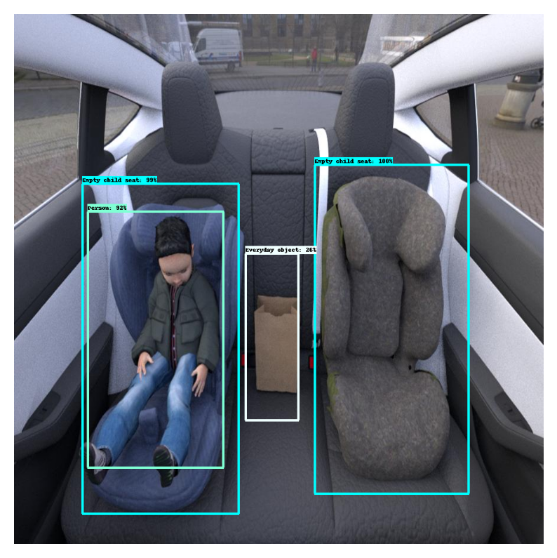

```python
run_detection('/content/data/test/tesla_test_imageID_252_GT_6_0_3.jpeg')
```

## Next Steps

In a short time we were able to train a detection model to detect object/persons in the backseat of 2 different car models, BMW i3 and Tesla Model3, with an accuracy close to the ones found by the SVIRO team. More time is needed to investigate the best approach to train this model, such as:

- Train 1 model for each car and compare the results with a single model for every car model.
- Train model on the full dataset for each car model.
- Train model with a higher number of steps.
- Apply other data augmentation techniques such as, rotations, color distortion and image occlusion.
- Train model with a bigger BATCH_SIZE.

## Credits

- [SVIRO dataset](https://sviro.kl.dfki.de/)
- [Tensorflow object detection](https://www.tensorflow.org/hub/tutorials/tf2_object_detection)
- [EfficientNet](https://ai.googleblog.com/2019/05/efficientnet-improving-accuracy-and.html)
- [EfficientDet](https://arxiv.org/abs/1911.09070)